# lecture14

author: date:

# more about plyr

In honor of world series, I’ll start witha baseball example.

```r
head(baseball)[, c(1, 2, 4, 6:9)]
```

```
##            id year team  g  ab  r  h
## 4   ansonca01 1871  RC1 25 120 29 39
## 44  forceda01 1871  WS3 32 162 45 45
## 68  mathebo01 1871  FW1 19  89 15 24
## 99  startjo01 1871  NY2 33 161 35 58
## 102 suttoez01 1871  CL1 29 128 35 45
## 106 whitede01 1871  CL1 29 146 40 47
```

========

```r
tail(baseball)[, c(1, 2, 4, 6:9)]
```

```
##              id year team   g  ab  r   h
## 89523 biggicr01 2007  HOU 141 517 68 130
## 89525 benitar01 2007  FLO  34   0  0   0
## 89526 benitar01 2007  SFN  19   0  0   0
## 89530 ausmubr01 2007  HOU 117 349 38  82
## 89533  aloumo01 2007  NYN  87 328 51 112
## 89534 alomasa02 2007  NYN   8  22  1   3
```

```r
dim(baseball)
```

```
## [1] 21699    22
```

# 2 functions: “transform” & “summarize”

transform

```r
# the trasnform function will take in a dataframe everything after the
# dataframe will be added as a column to the dataframe
standings <- data.frame(name = c("Mets", "Royals"), W = c(90, 95), L = c(72,
    67))
transform(standings, win.perc = round(W/(W + L), 2), games = W + L)
```

```
##     name  W  L win.perc games
## 1   Mets 90 72     0.56   162
## 2 Royals 95 67     0.59   162
```

# 2 functions: “transform” & “summarize”

summarize

```r
# summarise does similar things as transform But instead it creates a new
# data frame with just the new columns
standings <- data.frame(name = c("Mets", "Royals"), W = c(90, 95), L = c(72,
    67))
summarise(standings, win.perc = round(W/(W + L), 2), games = W + L)
```

```
##   win.perc games
## 1     0.56   162
## 2     0.59   162
```

# Goal: plot year as pro versus mean home run per at bat

1. Add column to baseball dataset with year as pro for each player, each year.
2. Calculate mean HR per at bat for possible values of year as pro
3. Make CI around that mean too

When doing something complicated, I usually write simpler functions first.

# Add a column to baseball with year in league

Get data for one player and try it

```r
carl.y <- subset(baseball,id=="yastrca01")
head(carl.y)[,c(1,2,4,6:9)]
```

```
##              id year team   g  ab  r   h
## 41638 yastrca01 1961  BOS 148 583 71 155
## 42318 yastrca01 1962  BOS 160 646 99 191
## 43072 yastrca01 1963  BOS 151 570 91 183
## 43821 yastrca01 1964  BOS 151 567 77 164
## 44575 yastrca01 1965  BOS 133 494 78 154
## 45336 yastrca01 1966  BOS 160 594 81 165
```

# Add a column to baseball with year in league

```r
# adding th column for the pro years
carl.y <- transform(carl.y,pro.year=year-min(year)+1)
names(carl.y)
```

```
##  [1] "id"       "year"     "stint"    "team"     "lg"       "g"
##  [7] "ab"       "r"        "h"        "X2b"      "X3b"      "hr"
## [13] "rbi"      "sb"       "cs"       "bb"       "so"       "ibb"
## [19] "hbp"      "sh"       "sf"       "gidp"     "pro.year"
```

# Use ddply to do it for each player (id)

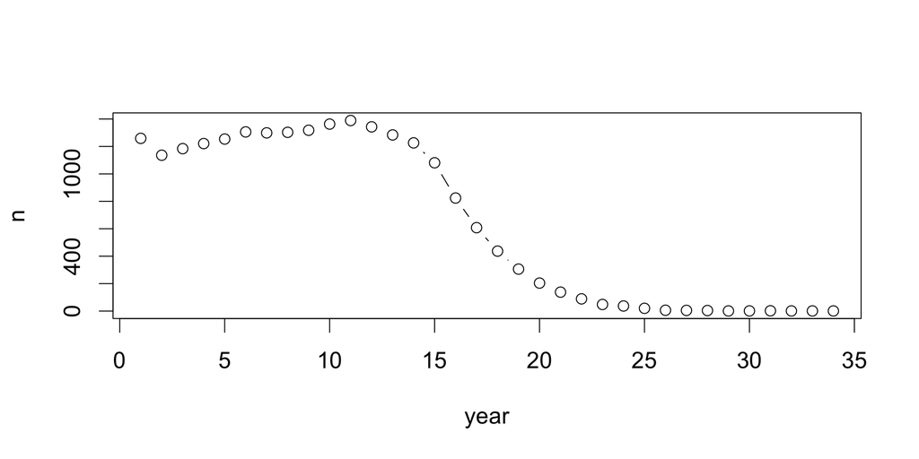

```r
par(cex = 1.5)
# here we give ddply dataframe- baseball splitting criteria - id function -
# transform the extra arguments to function - transform taking in
# pro.year...
baseball <- ddply(baseball, .(id), transform, pro.year = year - min(year) +
    1)
# use vectors to plot
plot(1:length(table(baseball$pro.year)), as.vector(table(baseball$pro.year)),
    xlab = "year", ylab = "n", type = "b")
```

# Get mean HR per AB (by pro year)

First do it for two players

```r
# take 2 players
two.carls <- subset(baseball,(id=="yastrca01")|(id=="fiskca01"))
```

How do we estimate the mean of a ratio? Let’s use maximum likelihood.

-calculate the home run average for each player each year

-then apply **ddply** to get the average of the ratios

**OR**

-calculate the total home run for each pro.year

-calculate the total at bat for each pro.year

-Take the ratio of those totals for each pro.year

# Calculate mean ratio

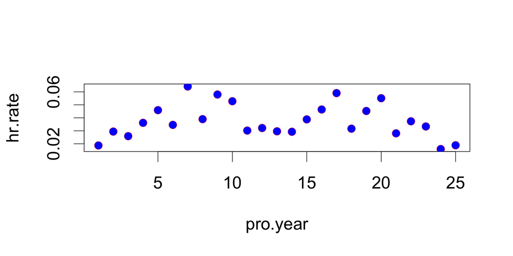

```r
par(cex=2)
hr.per.ab.1 <- ddply(two.carls,.(pro.year),summarize,hr.rate=sum(hr)/sum(ab))
plot(hr.per.ab.1,col="red")
points(hr.per.ab.1,pch=16,col="blue")
```

# Add n and se

```r
# n= length of the id
# making a data frame with pro.year, home run rate and n
hr.rate.sum <- ddply(two.carls,.(pro.year),summarize,hr.rate=sum(hr)/sum(ab),n=length(id))
# adding the standard error
# getting the standard error of each p hats
hr.rate.sum <- transform(hr.rate.sum,se=sqrt(hr.rate*(1-hr.rate)/n))
head(hr.rate.sum)
```

```
##   pro.year    hr.rate n         se
## 1        1 0.01870748 2 0.09580583
## 2        2 0.02941176 1 0.16895772
## 3        3 0.02588997 2 0.11229354
## 4        4 0.03613281 2 0.13196066
## 5        5 0.04590818 2 0.14798754
## 6        6 0.03457106 2 0.12918186
```

# Do it for all the data

```r
# same for all data
hr.rate.sum <- ddply(baseball, .(pro.year), summarize, hr.rate = sum(hr)/sum(ab),
    n = length(id))
hr.rate.sum <- transform(hr.rate.sum, se = sqrt(hr.rate * (1 - hr.rate)/n))
head(hr.rate.sum)
```

```
##   pro.year    hr.rate    n          se
## 1        1 0.01445766 1259 0.003364138
## 2        2 0.01808048 1136 0.003953245
## 3        3 0.01930078 1184 0.003998338
## 4        4 0.02145564 1221 0.004146705
## 5        5 0.02263542 1254 0.004200237
## 6        6 0.02325279 1306 0.004170202
```

# Make CIs

```r
# now getting the CIs
hr.rate.sum <- transform(hr.rate.sum, lower = hr.rate - qt(0.975, df = n - 1) *
    se, upper = hr.rate + qt(0.975, df = n - 1) * se)
# replace NAN with 0
hr.rate.sum[hr.rate.sum == "NaN"] <- 0
head(hr.rate.sum)
```

```
##   pro.year    hr.rate    n          se      lower      upper
## 1        1 0.01445766 1259 0.003364138 0.00785772 0.02105760
## 2        2 0.01808048 1136 0.003953245 0.01032399 0.02583696
## 3        3 0.01930078 1184 0.003998338 0.01145616 0.02714540
## 4        4 0.02145564 1221 0.004146705 0.01332018 0.02959111
## 5        5 0.02263542 1254 0.004200237 0.01439514 0.03087569
## 6        6 0.02325279 1306 0.004170202 0.01507176 0.03143383
```

# Make a nice plot!

```r
par(cex = 2)
ylim <- range(c(hr.rate.sum$lower, hr.rate.sum$upper))
plot(hr.rate.sum$pro.year, hr.rate.sum$hr.rate, ylim = ylim, xlab = "pro year",
    ylab = "HR rate (95% CI)", type = "n", axes = F)
lines(hr.rate.sum$pro.year, hr.rate.sum$hr.rate, lwd = 2)
lines(hr.rate.sum$pro.year, hr.rate.sum$upper, col = "red", lwd = 3)
lines(hr.rate.sum$pro.year, hr.rate.sum$lower, col = "red", lwd = 3)
axis(1)
axis(2)
```

Depending on what you are look for. You can cut the plot off at the early part of the carrer of the player

# Make a nice plot! (not this one!)

[figure not shown]

# Make a nicer plot!

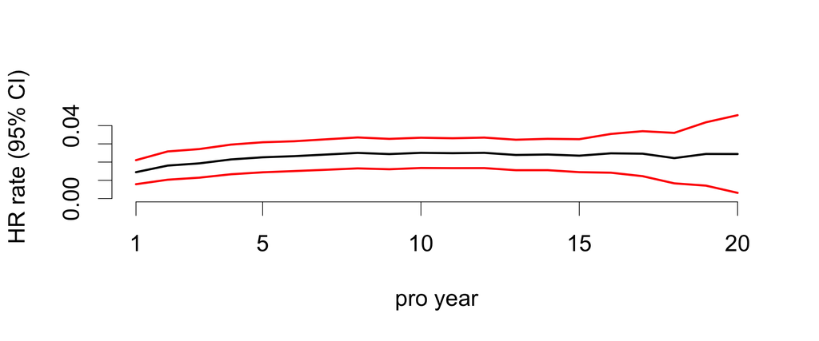